# Oefening II - Correlatie basis

# Basisbegrippen in de Correlation

## 📋 OVERZICHTSTABEL - VRAGEN VOLGENS BLOOM’S TAXONOMIE (25 VRAGEN)

### ONTHOUDEN NIVEAU (5 vragen - 20%)

[output not shown]

### NIVEAU BEGRIJPEN (13 vragen - 52%)

| Vraagnummer | Vraag Titel | Leerintentie |
| --- | --- | --- |
| Q6 | Variabeletypen voor correlatie | Variabeletypes voor correlatie begrijpen |
| Q7 | Basisprincipes van correlatie versus causaliteit | Verschil correlatie-causatie begrijpen |
| Q8 | Correlatiewaarden interpreteren | Correlatie-interpretatie begrijpen |
| Q9 | Wat correlatie ons vertelt | Richting, sterkte en betekenis van correlatie begrijpen |
| Q10 | Covariantie versus correlatie | Verschil tussen covariantie en correlatie begrijpen |
| Q11 | Visualisatie belang | Belang van visualisatie begrijpen |
| Q12 | Covariantie versus correlatie | Verschil covariantie-correlatie begrijpen |
| Q13 | Wanneer correlatie misleidend kan zijn | Beperkingen van correlatie begrijpen |
| Q17 | Correlatie types | Verschillende correlatie types begrijpen |
| Q18 | Wanneer welke correlatie gebruiken | Correlatie types toepassing begrijpen |
| Q20 | Waarom standardisatie nodig is | Standardisatie noodzaak begrijpen |
| Q21 | Correlatie interpretatie | Correlatie interpretatie begrijpen |
| Q23 | Correlatie veronderstellingen | Correlatie aannames begrijpen |

### TOEPASSEN NIVEAU (3 vragen - 12%)

| Vraagnummer | Vraag Titel | Leerintentie |
| --- | --- | --- |
| Q14 | Pearson vs Spearman voor niet-lineaire relaties | Monotoon versus lineair toepassen |
| Q15 | Richting en kracht | Richting en sterkte bepalen |
| Q16 | Zwak positief | Zwak positieve correlatie herkennen |

### ANALYSEER NIVEAU (1 vraag - 4%)

| Vraagnummer | Vraag Titel | Leerintentie |
| --- | --- | --- |
| Q19 | Impact van uitschieters | Impact van uitbijters analyseren |

### NIVEAU EVALUEREN (1 vraag - 4%)

| Vraagnummer | Vraag Titel | Leerintentie |
| --- | --- | --- |
| Q22 | Statistische declaraties beoordelen | Statistische claims beoordelen |

### CREATIE NIVEAU (2 vragen - 8%)

| Vraagnummer | Vraag Titel | Leerintentie |
| --- | --- | --- |
| Q24 | Ontwerp een correlatiestudie | Correlatiestudie ontwerpen |
| Q25 | Onderzoekshypothese opstellen | Onderzoekshypothese formuleren |

## ONTHOUDEN NIVEAU (5 vragen)

### Vraag Q1 (Onthouden)

**Wat is correlatie?**

> Hint: Denk na over hoe twee criminologische variabelen samen bewegen - bijvoorbeeld werkloosheid en misdaadcijfers - niet over oorzaak en gevolg.
1. Een statistische maat voor de sterkte en richting van de relatie tussen twee variabelen “1” = ” ✅ Juist! Correlatie kwantificeert hoe sterk en in welke richting twee kwantitatieve variabelen met elkaar in verband staan. Een positieve correlatie (bijv. r = +0,68 tussen werkloosheid en vermogenscriminaliteit) betekent dat hogere werkloosheid gepaard gaat met hogere criminaliteit, terwijl een negatieve correlatie (bijv. r = –0,55 tussen zichtbaarheid van de politie en wanorde) betekent dat naarmate de ene toeneemt, de andere afneemt.”
2. Een maat voor de mate waarin de ene variabele de andere veroorzaakt “2” = ” ❌ Fout. Dit is een veel voorkomende misvatting in onderzoek. Correlatie laat zien dat twee variabelen samen veranderen, maar het bewijst niet dat de ene de andere veroorzaakt. Buurten met een hoge werkloosheid hebben bijvoorbeeld vaak hogere misdaadcijfers, maar dit kan het gevolg zijn van een derde factor, zoals armoede, sociale desorganisatie of zwakke informele controle.”
3. Het verschil tussen twee variabelen “3” = ” ❌ Fout. Het nemen van een verschil (Y - X) meet alleen een kloof, niet of de variabelen samen variëren. Het verschil tussen diefstal- en mishandelingspercentages zegt bijvoorbeeld niets over de vraag of deze misdaden samen stijgen of dalen. Correlatie onderzoekt co-variatie - hoeveel beide variabelen afwijken van hun gemiddelden in dezelfde of tegengestelde richting.”
4. Een methode om toekomstige waarden te voorspellen “4” = ” ❌ Fout. Dat is regressieanalyse, geen correlatie. Regressie stelt criminologen in staat om bijvoorbeeld het verwachte misdaadcijfer voor een bepaald werkloosheidsniveau te voorspellen. Correlatie vat alleen samen hoe twee variabelen op een bepaald moment in de tijd met elkaar in verband staan - het kan geen voorspellingen doen of oorzakelijk verband bewijzen.”

### Vraag Q2 (Onthouden)

**Wat is een z-score?**

> **Hint:** Denk na over het vergelijken van misdaadstatistieken in verschillende rechtsgebieden of tijdsperioden - hoe weten we of een misdaadcijfer ongewoon hoog of laag is in vergelijking met het typische patroon?
1. De ruwe score minus het gemiddelde  
   “1” = ” ❌ Fout. Dit geeft u een afwijkingsscore, die aangeeft hoe ver boven of onder het gemiddelde een waarde is, maar geen rekening houdt met de variabiliteit in uw gegevens. Als het gemiddelde misdaadcijfer bijvoorbeeld 50 per 1.000 is en een stad 60 per 1.000 heeft, is de afwijking +10. Maar we kunnen niet beoordelen of dit ‘veel’ is zonder te weten of misdaadcijfers doorgaans variëren met ±2 of ±20 rond het gemiddelde. De z-score standaardiseert dit door te delen door de standaarddeviatie.”
2. Het percentage boven het gemiddelde  
   “2” = ” ❌ Fout. Z-scores worden uitgedrukt in standaarddeviatie-eenheden, niet in percentages. Z-scores kunnen echter worden geconverteerd naar percentielen met behulp van de normale verdeling. z = +1,0 komt bijvoorbeeld overeen met ongeveer het 84e percentiel (wat betekent dat 84% van de waarden onder dit punt valt), maar de z-score zelf is geen percentage. In de criminologie is dit onderscheid van belang bij het interpreteren van risicobeoordelingen of het vergelijken van misdaadstatistieken in verschillende rechtsgebieden.”
3. Een score die aangeeft hoeveel standaarddeviaties een waarde is ten opzichte van het gemiddelde  
   “3” = ” ✅ Juist! Z-scores standaardiseren waarden met behulp van de formule z = (X - μ)/σ, waardoor zinvolle vergelijkingen tussen verschillende variabelen of tijdsperioden mogelijk zijn. Als het geweldsmisdrijfcijfer van een stad bijvoorbeeld z = +2,1 heeft, betekent dit dat het 2,1 standaarddeviaties boven het gemiddelde voor alle steden ligt - een ongewoon hoog percentage. Met Z-scores kunnen we vergelijken ‘hoe ongebruikelijk’ verschillende soorten criminaliteit zijn: een inbraakcijfer met z = +1,5 en een mishandelingspercentage met z = +0,8 duiden beide op bovengemiddelde criminaliteit, maar inbraak is extreem hoog.”
4. Het kwadraat van de originele partituur  
   “4” = ” ❌ Fout. Het kwadrateren van een score zou de schaal drastisch veranderen en informatie verliezen over de vraag of de oorspronkelijke waarde boven of onder het gemiddelde lag. Z-scores behouden de relatieve positie terwijl ze de schaal standaardiseren. Als we de misdaadcijfers in het kwadraat zouden brengen, zou een stad met 100 misdaden per 1.000 10.000 worden - waardoor de betekenis volledig zou veranderen en vergelijkingen onmogelijk zouden worden.”

### Vraag Q3 (Onthouden)

**Een criminoloog heeft een onderzoek uitgevoerd naar verschillende criminaliteitsvariabelen in 45 Belgische gemeenten. Zij heeft gegevens verzameld over politieaanwezigheid, drugsdelicten, geweldsdelicten en vermogenscriminaliteit. Nu moet zij een correlatiematrix rapporteren zijn de belangrijkste maatregelen in correlatieanalyse?**

> **Hint:** Bij het bestuderen van de relatie tussen twee misdaadgerelateerde variabelen, welke statistieken heb je dan nodig om de associatie volledig te begrijpen en te rapporteren?

=== DESCRIPTIVE STATISTICS ===

Politieaanwezigheid (agenten per 1000 inwoners): Mean (M): 4.12 Standard Deviation (SD): 1.3 Variance: 1.68

Drugsdelicten (per 1000 inwoners): Mean (M): 25.96 Standard Deviation (SD): 9.58 Variance: 91.86

=== CORRELATION ANALYSIS ===

Correlation coefficient (r): -0.834 Coefficient of determination (R²): 0.696 Explained variance: 69.6 % Sample size (n): 45 p-value: 0 Significance: p < .001 ***

1. De helling en het snijpunt  
   “1” = ” ❌ Fout. Helling en snijpunt zijn regressieparameters, geen correlatiematen. Hoewel regressie en correlatie gerelateerd zijn (helling = r × sy/sx), dienen ze verschillende doelen. Correlatie vat de kracht van associatie samen; Regressie biedt voorspellingsvergelijkingen. In de criminologie zou je correlatie kunnen rapporteren bij het bestuderen of twee soorten criminaliteit de neiging hebben om samen voor te komen, maar regressie bij het voorspellen van toekomstige misdaadcijfers op basis van demografische factoren.”
2. Alleen het gemiddelde en de standaarddeviatie  
   “2” = ” ❌ Fout. Gemiddelden en standaarddeviaties beschrijven individuele variabelen, maar geven niet de relatie tussen twee variabelen weer. Je zou identieke gemiddelden en standaarddeviaties kunnen hebben voor werkloosheids- en misdaadcijfers in twee verschillende onderzoeken, maar totaal verschillende correlaties (r = +0,80 vs. r = -0,20). Correlatieanalyse onderzoekt specifiek hoe variabelen samen variëren, wat andere statistieken vereist dan eenvoudige beschrijvende metingen.”
3. Alleen de correlatiecoëfficiënt (r)  
   “3” = ” ❌ Fout. Hoewel r de primaire maatstaf is, levert het rapporteren van alleen r onvolledige informatie op voor onderzoek. U moet ook weten hoeveel variantie wordt verklaard (R²) en of uw steekproefomvang (n) groot genoeg is om het resultaat te vertrouwen. R = 0,40 tussen aanwezigheid van de politie en misdaadvermindering lijkt bijvoorbeeld zinvol, maar als n = 8 steden, is het resultaat onbetrouwbaar. Professioneel onderzoek vereist het rapporteren van alle drie de statistieken.”
4. Correlatiecoëfficiënt (r), bepalingscoëfficiënt (R²) en steekproefomvang (n)  
   “4” = ” ✅ Juist! Deze drie geven volledige informatie over de relatie. De correlatiecoëfficiënt (r) geeft de sterkte en richting aan (-1 tot +1), R² geeft het verklaarde variantiepercentage aan (r² × 100%) en de steekproefomvang (n) geeft betrouwbaarheid aan. Bijvoorbeeld: ‘De zichtbaarheid en wanorde van de politie vertoonden een matige negatieve correlatie (r = -0,45, R² = 0,20, n = 150 buurten), wat aangeeft dat 20% van de variatie in wanorde kan worden verklaard door de aanwezigheid van de politie.’ Dit geeft lezers alle informatie die nodig is om de bevinding te evalueren.”

### Vraag Q4 (Onthouden)

**Wat betekent een correlatiecoëfficiënt van r = 0?**

### Vraag Q5 (Onthouden)

**Een onderzoeker bestudeert de relatie tussen patrouille-afstanden en politie-responssnelheid in 50 Belgische steden. Haar oorspronkelijke data toont een correlatie van r = -0,65 tussen gemiddelde patrouille-afstand (in meters) en responssnelheid (in minuten). Voor internationale vergelijking met Amerikaanse data (die feet gebruikt, 1 meter = 3,28 feet) moet zij de Belgische afstanden omrekenen van meters naar feet. Wat gebeurt er met de correlatiecoëfficiënt r tussen patrouille-afstand en responssnelheid na deze eenheidsconversie?**

> **Hint:** Overweeg hoe eenheidsconversies (meters naar centimeters, of misdaadcijfers per 1.000 versus per 100.000 inwoners) de correlatie tussen variabelen beïnvloeden.
1. r wordt 100× groter  
   “1” = ” ❌ Fout. Eenheden hebben geen invloed op de correlatiemagnitude. Dit is een cruciale eigenschap voor onderzoek waarbij variabelen vaak verschillende schalen gebruiken. De correlatie tussen ‘jaren onderwijs’ en ‘arrestaties per 1.000 inwoners’ zou bijvoorbeeld hetzelfde zijn als de correlatie tussen ‘jaren onderwijs’ en ‘arrestaties per 100.000 inwoners’. De schaalverandering verandert niets aan de onderliggende relatiesterkte. Als veranderende eenheden de correlatie zouden beïnvloeden, zou vergelijkend onderzoek in landen met verschillende meetsystemen onmogelijk zijn.”
2. r wordt 100× kleiner  
   “2” = ” ❌ Fout. Nogmaals, correlatie is schaalinvariant. Of u nu de reactietijd van patrouillewagens meet in seconden, minuten of uren, de correlatie met de opruimingspercentages van misdrijven blijft identiek. Deze eigenschap maakt correlatie bijzonder waardevol voor internationale criminologische vergelijkingen - onderzoekers kunnen gegevens gebruiken die in verschillende eenheden zijn gemeten zonder wiskundige aanpassingen. De relatiesterkte tussen twee variabelen is onafhankelijk van hoe die variabelen worden geschaald.”
3. r blijft precies hetzelfde  
   “3” = ” ✅ Juist! Correlatie is eenheidsvrij en invariant voor lineaire herschaling. Dit komt omdat correlatie beide variabelen tijdens de berekening standaardiseert - het meet hoe variabelen samen bewegen ten opzichte van hun eigen variabiliteit, ongeacht de eenheden. In de criminologie betekent dit dat je correlaties kunt vergelijken tussen onderzoeken die verschillende meetschalen gebruiken. Studies die bijvoorbeeld misdaadcijfers per hoofd van de bevolking versus per vierkante kilometer meten, kunnen nog steeds vergelijkbare correlatiecoëfficiënten hebben met demografische factoren. Deze invariantie-eigenschap maakt correlatie tot een universele maat voor associatie.”
4. r wordt negatief  
   “4” = ” ❌ Fout. Veranderingen in eenheden kunnen de richting van een relatie niet omdraaien. Als een verhoogde aanwezigheid van de politie gepaard gaat met een verminderde criminaliteit (negatieve correlatie), blijft deze relatierichting hetzelfde, of je nu de aanwezigheid van agenten per blok, per vierkante kilometer of per 1.000 inwoners meet. Alleen de schaal verandert, niet het fundamentele patroon. Een sign flip zou duiden op een heel andere substantiële relatie, die eenheidsconversie niet kan veroorzaken.”

### Vraag Q6 (Begrijpen)

**Voor welke soorten variabelen kunt u de Pearson-correlatie berekenen?**

> Hint: Overweeg of je de correlatie tussen verschillende soorten variabelen zinvol kunt berekenen - kun je geslacht correleren met misdaadcijfers? Lengte van de gevangenisstraf met kans op recidive?
1. Elk type variabelen  
   “1” = ” ❌ Fout. Er bestaan verschillende correlatiematen voor verschillende variabelecombinaties. Pearson-correlatie is specifiek voor continue variabelen. Andere metingen zijn: Spearman’s rho voor gerangschikte gegevens, phi-coëfficiënt voor twee binaire variabelen, Cramér’s V voor twee categorische variabelen en point-biserial voor één binaire en één continue variabele. Het gebruik van het verkeerde correlatietype kan leiden tot nietszeggende resultaten of ernstige verkeerde interpretaties van relaties in onderzoek.”
2. Een categorische en een continue variabele  
   “2” = ” ❌ Fout. Als u één categorische en één continue variabele hebt, gebruikt u punt-biseriële correlatie (voor binaire categorieën) of eta-correlatie (voor meerdere categorieën). Als je bijvoorbeeld de relatie tussen geslacht (categorisch: man/vrouw) en het aantal arrestaties (continu) bestudeert, zou je punt-biseriële correlatie gebruiken. Als je de relatie tussen het type buurt (categorisch: stedelijk/voorstedelijk/landelijk) en het misdaadcijfer (continu) onderzoekt, zou je ANOVA- of eta-correlatie kunnen gebruiken in plaats van Pearson-correlatie.”
3. Beide variabelen moeten continu zijn (interval- of rationiveau)  
   “3” = ” ✅ Juist! Pearson-correlatie vereist dat beide variabelen worden gemeten op interval- of rationiveau - numerieke variabelen waarbij de afstanden tussen waarden zinvol en consistent zijn. In de criminologie zijn voorbeelden: misdaadcijfers (ratio), strafduur in maanden (ratio), leeftijd bij eerste arrestatie (ratio), aantal eerdere veroordelingen (ratio) en schalen die de houding ten opzichte van de politie meten (interval). Deze variabelen maken zinvolle wiskundige bewerkingen mogelijk die nodig zijn voor het berekenen van gemiddelden, standaarddeviaties en covarianties die de basis vormen van de Pearson-correlatie.”
4. Alleen categorische variabelen  
   “4” = ” ❌ Fout. Pearson-correlatie vereist numerieke variabelen waarbij wiskundige bewerkingen (optellen, aftrekken, middelen) zinvol zijn. Categorische variabelen zoals ‘type misdaad’ (gewelddadig, eigendom, drugs) of ‘gerechtelijke beschikking’ (schuldig, niet schuldig, pleidooi) hebben geen inherente numerieke waarden. Je kunt geen zinvol gemiddelde berekenen van ‘gewelddadige’ en ‘eigendomsdelicten’. Voor categorische variabelen zou je verschillende maten gebruiken, zoals de V- of Chi-kwadraattest van Cramér om associaties te onderzoeken.”

### Vraag Q7 (Begrijpen)

**Waarom bewijst correlatie geen causatie?**

> **Hint:** Overweeg waarom een sterke correlatie tussen beveiligingscamera’s en misdaadcijfers, of tussen politieaanwezigheid en criminaliteit, niet noodzakelijk betekent dat het ene het andere veroorzaakt.
1. Derde variabelen, omgekeerde causaliteit of toeval kunnen de relatie verklaren  
   “1” = ” ✅ Juist! Correlatie kan geen causale richting vaststellen of alternatieve verklaringen uitsluiten. Drie hoofdproblemen: (1) Derde variabelen — armoede kan zowel een laag opleidingsniveau als hoge criminaliteit veroorzaken, wat een schijncorrelatie tussen onderwijs en criminaliteit creëert; (2) Omgekeerde causaliteit — verminderen meer politieagenten de criminaliteit, of leidt meer criminaliteit tot het aannemen van meer politie? (3) Toeval — twee variabelen kunnen per toeval correleren, vooral bij kleine steekproeven. Het vaststellen van causaliteit vereist gecontroleerde experimenten, longitudinale ontwerpen, natuurlijke experimenten of geavanceerde statistische technieken die causale effecten kunnen isoleren van deze alternatieve verklaringen.”
2. Correlatie is altijd te zwak om iets te bewijzen  
   “2” = ” ❌ Fout. Zelfs zeer sterke correlaties (r = 0,90 of hoger) bewijzen geen causaal verband. Het probleem is niet de sterkte van de correlatie, maar de logica van causale inferentie. Bijvoorbeeld, u kunt een zeer sterke correlatie (r = 0,85) vinden tussen het aantal beveiligingscamera’s in een buurt en misdaadcijfers, maar dit bewijst niet dat camera’s criminaliteit veroorzaken. De hoge correlatie kan bestaan omdat camera’s worden geïnstalleerd als reactie op hoge criminaliteit, niet omdat camera’s criminaliteit veroorzaken. Correlatiesterkte en causaal bewijs zijn compleet gescheiden kwesties.”
3. Alleen experimenten kunnen relaties aantonen  
   “3” = ” ❌ Fout. Correlatie toont duidelijk aan dat relaties bestaan — het kan alleen niet bepalen of ze causaal zijn. Veel belangrijke relaties kunnen om ethische redenen niet experimenteel worden bestudeerd (je kunt mensen niet willekeurig toewijzen aan criminele carrières). Correlationele studies leveren waardevol bewijs over associaties, risicofactoren en patronen. Hoewel experimenten het sterkste causale bewijs leveren, kunnen observationele studies met technieken zoals instrumentele variabelen, regressiediscontinuïteit of natuurlijke experimenten ook overtuigend causaal bewijs leveren wanneer experimenten niet haalbaar zijn.”
4. Correlatie is hetzelfde als causaliteit  
   “4” = ” ❌ Fout. Dit is precies het misverstand dat onderzoekers moeten vermijden. Media-berichten beweren vaak ‘studies tonen aan dat X Y veroorzaakt’ wanneer het onderzoek alleen correlatie heeft aangetoond. Het vinden dat wijken met meer straatverlichting minder criminaliteit hebben, bewijst bijvoorbeeld niet dat straatverlichting criminaliteit voorkomt — veiligere wijken kunnen simpelweg meer geneigd zijn om straatverlichting te installeren. Het begrijpen van dit onderscheid is cruciaal voor evidence-based strafrechtelijk beleid, aangezien het implementeren van interventies op basis van alleen correlationeel bewijs middelen kan verspillen of zelfs averechts kan werken.”

### Vraag Q8 (Begrijpen)

**Een criminoloog onderzoekt de relatie tussen sociale cohesie in buurten (onderlinge verbondenheid en samenwerking tussen bewoners) en de effectiviteit van misdaadpreventie in 75 Belgische gemeenten. Na het verzamelen van data over gemeenschapsbetrokkenheid en lokale veiligheidsprogramma’s, berekent ze een correlatie van r = 0,75. Hoe moet zij deze bevinding interpreteren voor haar rapport aan het Ministerie van Justitie en Veiligheid?**

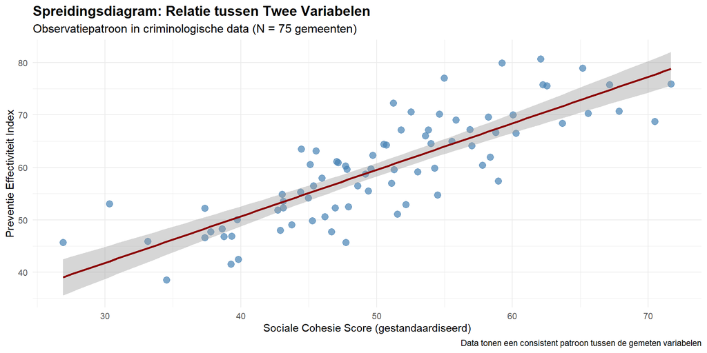

> **Hint:** Overweeg wat een correlatie van r = 0,75 betekent in termen van relatiesterkte, praktische betekenis voor beleid, en hoe dit zou moeten worden gecommuniceerd aan beleidsmakers.
1. Perfecte negatieve relatie - tegengesteld effect van verwachting  
   “1” = ” ❌ Fout. Deze interpretatie heeft twee grote fouten: (1) r = 0,75 is positief, niet negatief — de waarde ligt boven nul, wat aangeeft dat variabelen in dezelfde richting bewegen; (2) 0,75 is sterk maar niet perfect — een perfecte correlatie zou r = ±1,00 zijn. Een perfecte negatieve correlatie (r = -1,00) betekent dat wanneer sociale cohesie toeneemt, preventie effectiviteit in exact dezelfde verhouding afneemt, zonder uitzonderingen. In de criminologie zijn perfecte correlaties vrijwel onmogelijk vanwege de complexiteit van sociale fenomenen en meetfouten.”
2. Sterke positieve relatie - significante bevinding voor preventiebeleid  
   “2” = ” ✅ Juist! Waarden rond 0,7-0,8 geven sterke positieve associaties aan in sociaalwetenschappelijk onderzoek. Een r = 0,75 betekent dat wanneer sociale cohesie toeneemt, de effectiviteit van preventie programma’s substantieel toeneemt in een voorspelbaar patroon. In de Nederlandse criminologie context kan dit de empirische basis bieden voor investeringen in gemeenschapsopbouw als onderdeel van misdaadpreventie strategieën. De relatie is sterk genoeg om praktisch betekenisvol te zijn voor beleid en voorspelling, waarbij sociale cohesie ongeveer 56% van de variantie in preventie effectiviteit verklaart. Dit suggereert dat gemeenten met sterkere sociale bindingen waarschijnlijk meer succesvol zijn met hun veiligheidsprogramma’s.”
3. Zwakke positieve relatie - minimale beleidsimplicaties  
   “3” = ” ❌ Fout. Een r = 0,75 vertegenwoordigt een sterke relatie, niet zwak. In criminologisch onderzoek worden correlaties rond 0,75 als behoorlijk substantieel beschouwd. Ter vergelijking: de correlatie tussen lengte en gewicht bij volwassenen is typisch rond 0,70-0,80. Als je r = 0,75 vond tussen buurt sociale cohesie en misdaadpreventie effectiviteit, zou dit wijzen op een sterk positief verband — als sociale cohesie toeneemt, neigen preventie programma’s aanzienlijk effectiever te worden. Dit correlatieniveau suggereert dat de variabelen ongeveer 56% van hun variantie delen (0,75² = 0,56), wat aanzienlijk is in sociaalwetenschappelijk onderzoek en belangrijke beleidsimplicaties heeft.”
4. Geen betekenisvolle relatie - resultaten zijn statistisch ruis  
   “4” = ” ❌ Fout. Een r = 0,75 geeft een sterke en betekenisvolle relatie aan, niet de afwezigheid ervan of statistische ruis. ‘Geen relatie’ zou worden aangegeven door r ≈ 0,00. Om r = 0,75 in perspectief te plaatsen: veel belangrijke relaties in de criminologie zijn zwakker dan dit — bijvoorbeeld, de correlatie tussen individuele risicofactoren en daadwerkelijk crimineel gedrag kan r = 0,30-0,50 zijn. Het vinden van r = 0,75 tussen sociale cohesie en preventie effectiviteit zou worden beschouwd als een substantiële en praktisch belangrijke associatie die verdere investering in gemeenschapsgerichte preventie strategieën rechtvaardigt.”

### Vraag Q9 (Begrijpen)

**Wat vertelt een correlatie ons over de relatie tussen twee variabelen?**

> **Hint:** Denk aan zowel wat correlatie meet (richting en sterkte) als wat het niet kan vertellen (causaliteit). Wat kan je afleiden uit een correlatiecoëfficiënt?
1. Hoeveel de ene variabele de andere veroorzaakt  
   “1” = ” ❌ Fout. Correlatie meet associatie, niet causaliteit. Dit is een cruciaal onderscheid in onderzoek. Een correlatie tussen eenoudergezinnen en jeugddelinquentie vertelt ons bijvoorbeeld niet dat eenoudergezinnen delinquentie veroorzaken — beide kunnen worden beïnvloed door armoede, buurtfactoren of andere variabelen. Een negatieve correlatie tussen aanwezigheid van de politie en misdaadcijfers kan betekenen: (1) politie vermindert criminaliteit (causaal), (2) gebieden met veel criminaliteit krijgen meer politie (omgekeerde causaliteit), of (3) beide worden beïnvloed door een derde factor zoals rijkdom in de buurt (schijncorrelatie). Verwarring van correlatie met causaliteit leidt tot verkeerd gerichte beleidsmaatregelen en interventies.”
2. Het verschil tussen twee groepsgemiddelden “2” = ” ❌ Fout. Het vergelijken van groepsgemiddelden gebruikt t-tests of ANOVA, niet correlatie. Het vergelijken van gemiddelde recidivecijfers tussen overtreders die een arbeidstraining hebben gekregen versus degenen die dat niet hebben gekregen, zou bijvoorbeeld een t-test gebruiken om het verschil in gemiddelden te onderzoeken. Correlatie onderzoekt hoe twee continue variabelen co-variëren (bijv. hoe individuele recidive-risicoscores gerelateerd zijn aan de daadwerkelijke frequentie van recidive). De statistische benaderingen en interpretaties zijn volledig verschillend — groepsvergelijkingen richten zich op verschillen tussen categorieën, terwijl correlatie zich richt op lineaire relaties tussen continue metingen.”
3. De richting en sterkte van een lineaire relatie tussen twee variabelen  
   “3” = ” ✅ Juist! Correlatie kwantificeert zowel richting als sterkte van hoe twee variabelen samen bewegen in een rechtlijnig patroon. De correlatiecoëfficiënt (r) vangt richting op via het teken (+ of -) en sterkte via de absolute waarde (0 tot 1). Positieve correlaties (+) betekenen dat variabelen in dezelfde richting bewegen: als het inkomen in de buurt toeneemt, nemen vastgoedwaarden toe. Negatieve correlaties (-) betekenen tegengestelde beweging: als de zichtbaarheid van de politie toeneemt, neemt straatcriminaliteit af. De sterkte vertelt hoe consistent deze relatie is: r = -0,80 is een sterkere relatie dan r = -0,30. Het begrijpen van zowel richting als sterkte is cruciaal voor het identificeren van risicofactoren (positieve correlatie met criminaliteit) versus beschermende factoren (negatieve correlatie).”
4. Hoeveel observaties er in de dataset zitten  
   “4” = ” ❌ Fout. De correlatierichting en -sterkte zijn onafhankelijk van de steekproefgrootte (n). Je kunt r = +0,60 hebben met n = 30 steden of n = 3.000 steden — zowel de positieve richting als de matige sterkte blijven hetzelfde. Steekproefgrootte beïnvloedt wel de betrouwbaarheid en statistische significantie van de correlatie, maar niet de richting of sterkte ervan. Grotere steekproeven leveren echter wel stabielere schattingen op van de richting en grootte van de correlatie, daarom proberen criminologische studies vaak veel jurisdicties of tijdsperioden op te nemen wanneer dat mogelijk is.”

### Vraag Q10 (Begrijpen)

**Wat is het belangrijkste verschil tussen covariantie en correlatie bij het meten van relaties tussen variabelen?**

> **Hint:** Denk aan wat er gebeurt wanneer je de meeteenheden van variabelen verandert. Welke maatstaf blijft hetzelfde en welke verandert?
1. Covariantie is altijd positief, correlatie kan negatief zijn  
   “1” = ” ❌ Fout. Beide maatstaven kunnen zowel positief als negatief zijn, afhankelijk van de richting van de relatie tussen variabelen. Covariantie kan variëren van negatief oneindig tot positief oneindig, terwijl correlatie varieert van -1 tot +1. Bijvoorbeeld, de relatie tussen politie-aanwezigheid en criminaliteitscijfers zou zowel een negatieve covariantie als een negatieve correlatie kunnen tonen, wat aangeeft dat meer politie-aanwezigheid geassocieerd is met lagere criminaliteitscijfers. De richting (positief of negatief) hangt af van de onderliggende relatie tussen de variabelen, niet van welke maatstaf je gebruikt.”
2. Covariantie hangt af van meeteenheden, correlatie is eenheidsvrij  
   “2” = ” ✅ Juist! Dit is het fundamentele onderscheid. Covariantie verandert wanneer je de schaal van variabelen wijzigt - als je inkomen meet in euro’s versus duizenden euro’s, krijg je verschillende covariantiewaarden voor dezelfde relatie. Correlatie blijft daarentegen constant ongeacht de meeteenheden omdat het een gestandaardiseerde maatstaf is. Bijvoorbeeld: de correlatie tussen buurtinkomen en criminaliteit blijft r = -0,45 of je inkomen meet in euro’s, duizenden euro’s, of dollars. Deze eenheidsvrije eigenschap maakt correlatie veel praktischer voor vergelijkende analyses en interpretatie, terwijl covariantie afhankelijk is van willekeurige keuzes in meeteenheden.”
3. Correlatie kan alleen waarden tussen 0 en 1 aannemen  
   “3” = ” ❌ Fout. Correlatie kan waarden aannemen tussen -1 en +1, niet alleen tussen 0 en 1. Het bereik van -1 tot +1 omvat zowel negatieve als positieve relaties. Een correlatie van -1 betekent een perfecte negatieve relatie (als de ene variabele toeneemt, neemt de andere perfect voorspelbaar af), 0 betekent geen lineaire relatie, en +1 betekent een perfecte positieve relatie. In criminologisch onderzoek zie je bijvoorbeeld vaak negatieve correlaties tussen sociaaleconomische status en criminaliteitscijfers (r = -0,60), wat aangeeft dat hogere sociaaleconomische status geassocieerd is met lagere criminaliteitscijfers.”
4. Beide maatstaven hebben hetzelfde interpretatiekader  
   “4” = ” ❌ Fout. Hoewel beide de richting van een relatie aangeven, hebben ze zeer verschillende interpretatiekaders. Covariantiewaarden hebben geen gestandaardiseerd bereik en zijn moeilijk te interpreteren zonder context van de oorspronkelijke variabelen - een covariantie van 500 kan sterk of zwak zijn afhankelijk van de schalen van de variabelen. Correlatie heeft daarentegen een vast interpretatiekader: waarden rond ±0,10 zijn zwak, rond ±0,30 zijn matig, rond ±0,50 zijn sterk, en boven ±0,70 zijn zeer sterk. Deze gestandaardiseerde interpretatie maakt correlatie veel praktischer voor onderzoekscommunicatie en vergelijkende analyses.”

### Vraag Q11 (Begrijpen)

**Een onderzoeker presenteert vier verschillende datasets van criminologische studies over de relatie tussen sociaaleconomische factoren en criminaliteit. Alle vier studies rapporteren precies dezelfde correlatiecoëfficiënt (r = 0,82), hetzelfde gemiddelde, en dezelfde standaarddeviatie. De onderzoeker concludeert dat alle studies identieke resultaten tonen. Wat is de belangrijkste methodologische les uit deze situatie?**

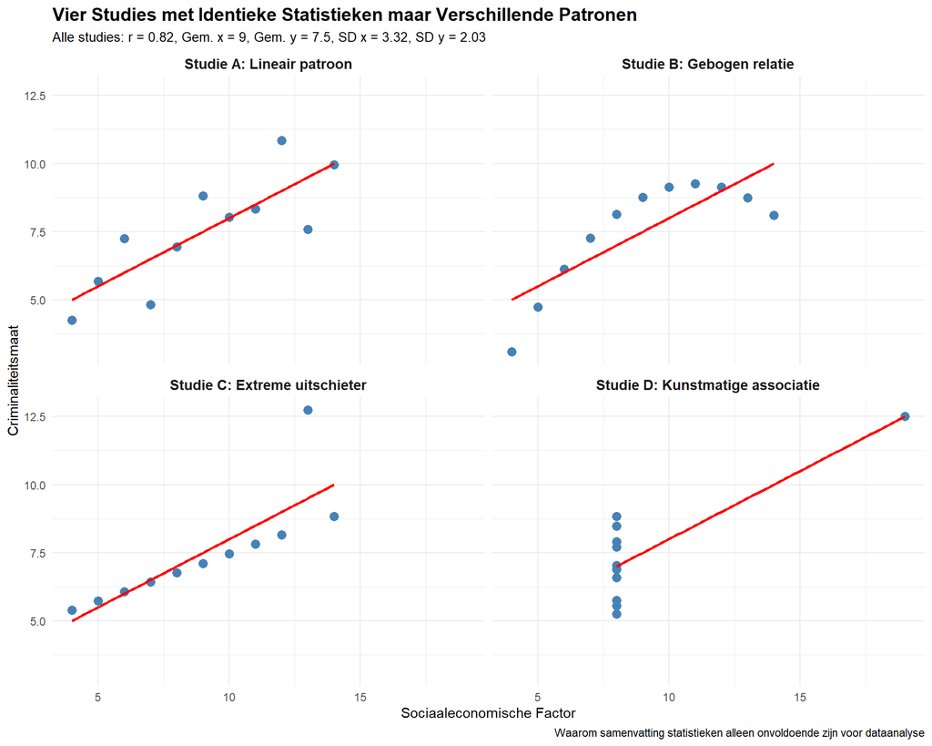

> **Hint:** Wanneer statistieken identiek zijn maar patronen verschillen, wat toont dit aan over de beperkingen van samenvatting getallen?
1. Correlatiecoëfficiënten vertellen het complete verhaal  
   “1” = ” ❌ Fout. Deze vier datasets tonen krachtig aan dat alleen correlatiecoëfficiënten diep misleidend kunnen zijn. Alle vier studies delen dezelfde identieke correlatie (r = 0,82), maar ze vertegenwoordigen fundamenteel verschillende relaties: Studie A toont een juiste lineaire relatie, Studie B onthult een gebogen (niet-lineair) patroon, Studie C bevat een invloedrijke uitschieter die de correlatie vertekent, en Studie D toont een kunstmatige associatie door één extreme datapunt. In onderzoek zou het vertrouwen op alleen correlatiecoëfficiënten leiden tot totaal verkeerde interpretaties van de onderliggende relaties.”
2. Visuele dataverkenning is essentieel voor betrouwbare analyse  
   “2” = ” ✅ Juist! Deze demonstratie toont waarom onderzoekers hun gegevens altijd moeten plotten voordat ze conclusies trekken. Alleen door de spreidingsdiagrammen te bekijken kunt u onderscheiden tussen een echte lineaire relatie, niet-lineaire patronen, invloedrijke uitschieters en kunstmatige associaties. In onderzoek kan dit het verschil betekenen tussen het identificeren van een echte trend (zoals de relatie tussen werkloosheid en eigendomscriminaliteit) versus het verkeerd interpreteren van gegevensartefacten. Visuele inspectie helpt onderzoekers de juiste analysemethode te kiezen en potentiële problemen met hun data te identificeren.”
3. Statistische samenvattingen zijn altijd voldoende voor conclusies  
   “3” = ” ❌ Fout. Dit is precies de mythe die deze demonstratie ontkracht. Hoewel correlatiecoëfficiënten en andere samenvattingen waardevolle informatie bieden, kunnen ze identiek zijn voor fundamenteel verschillende datapatronen. Zonder visuele inspectie kunt u een gebogen relatie missen die een ander type analyse vereist, een uitschieter negeren die uw resultaten vertekent, of een hefboompunt over het hoofd zien dat een schijnbare correlatie creëert. In criminologie kunnen dergelijke missers leiden tot verkeerde beleidsaanbevelingen.”
4. Studies met identieke correlaties hebben altijd dezelfde interpretatie  
   “4” = ” ❌ Fout. Dit misverstand ligt aan de basis van waarom deze demonstratie zo’n krachtig onderwijsinstrument is. Dezelfde correlatie kan ontstaan uit volkomen verschillende onderliggende patronen. In onderzoek zou dit betekenen dat verschillende mechanismen (lineaire trends, drempeleffecten, invloedrijke casussen, meetartefacten) allemaal dezelfde samengevatte correlatie kunnen produceren, maar totaal verschillende beleidsimplicaties hebben. Daarom is het cruciaal om altijd de ruwe data te visualiseren voordat interpretaties worden gemaakt.”

### Vraag Q12 (Begrijpen)

**Welke bewering over covariantie en correlatie is waar?**

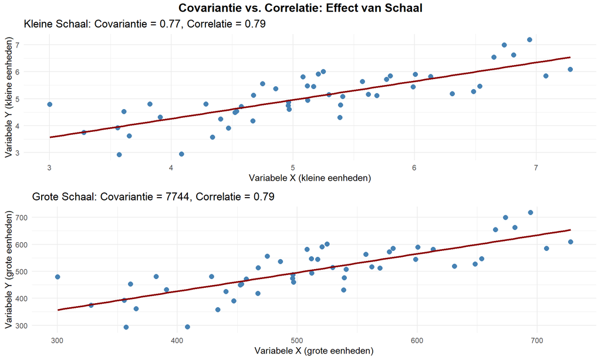

> **Hint:** Let op eenheden en bereiken.
1. Beide zijn afhankelijk van meetschaal  
   “1” = ” ❌ Fout. Een belangrijk onderscheid tussen deze maatstaven is dat covariantie afhangt van meetschaal terwijl correlatie dat niet doet. Als je eenheden verandert (bijv. van meters naar centimeters), zal de covariantie proportioneel veranderen, maar correlatie blijft onveranderd. Dit is waarom correlatie de voorkeur heeft voor vergelijkende analyse - het biedt een gestandaardiseerde maatstaf die niet wordt beïnvloed door willekeurige keuzes in meeteenheden. Het meten van temperatuur in Celsius versus Fahrenheit zou bijvoorbeeld verschillende covariantiewaarden opleveren, maar identieke correlatiecoëfficiënten bij het onderzoeken van relaties met andere variabelen.”
2. Covariantie is eenheidsvrij en begrensd tussen −1 en +1  
   “2” = ” ❌ Fout. Je hebt covariantie verward met correlatie. Covariantie is NIET eenheidsvrij en is NIET begrensd tussen -1 en +1. Covariantiewaarden hangen af van de meeteenheden (bijv. euro’s, kilogrammen, jaren) en kunnen variëren van negatief oneindig tot positief oneindig. Bijvoorbeeld, de covariantie tussen inkomen (gemeten in duizenden euro’s) en onderwijs (gemeten in jaren) kan 4,5 zijn, maar als inkomen in euro’s werd gemeten, zou de covariantie 4.500 zijn - een heel ander getal dat dezelfde relatiesterkte vertegenwoordigt.”
3. Correlatie is eenheidsvrij en altijd tussen −1 en +1  
   “3” = ” ✅ Juist! Correlatie (r) standaardiseert de relatie door covariantie te delen door het product van standaarddeviaties, waardoor een eenheidsvrije maatstaf ontstaat die altijd tussen -1 en +1 valt. Deze standaardisatie is waarom we correlatiewaarden zinvol kunnen vergelijken tussen verschillende variabelenparen ongeacht hun oorspronkelijke meetschalen. Bijvoorbeeld, r = 0,7 vertegenwoordigt dezelfde relatiesterkte of we nu lengte met gewicht correleren of testscores met studietijd. Deze begrensde, gestandaardiseerde aard maakt correlatie de voorkeursmaat voor het vergelijken van relatiesterkte tussen verschillende variabelenparen.”
4. Beide zijn onbegrensd  
   “4” = ” ❌ Fout. Hoewel covariantie inderdaad onbegrensd is (variërend van negatief oneindig tot positief oneindig), is correlatie specifiek ontworpen om begrensd te zijn tussen -1 en +1. Dit is een fundamenteel verschil tussen deze twee maatstaven. De begrensde aard van correlatie komt voort uit het normalisatieproces, waarbij covariantie wordt gedeeld door het product van standaarddeviaties. Deze wiskundige transformatie zorgt ervoor dat, ongeacht hoe groot de covariantie mogelijk is, de correlatiecoëfficiënt altijd binnen het gestandaardiseerde bereik van -1 tot +1 valt, waardoor het gemakkelijker te interpreteren en vergelijken is tussen verschillende analyses.”

### Vraag Q13 (Begrijpen)

**Wanneer kan een correlatiecoëfficiënt misleidend zijn bij het interpreteren van relaties tussen variabelen?**

> **Hint:** Denk aan situaties waar de numerieke correlatie niet het hele verhaal vertelt over de werkelijke relatie.
1. Wanneer er uitbijters (outliers) in de data zitten  
   “1” = ” ✅ Juist! Uitbijters kunnen correlatiecoëfficiënten drastisch beïnvloeden en misleidende resultaten geven. Een enkele extreme waarde kan een zwakke correlatie sterk doen lijken, of omgekeerd een sterke relatie verzwakken. Bijvoorbeeld, als je de relatie onderzoekt tussen leeftijd en criminaliteit, kan één zeer jonge verdachte met extreem veel arrestaties de hele correlatie vertekenen. Het is daarom essentieel om altijd spreidingsdiagrammen te maken en uitbijters te identificeren voordat je correlaties interpreteert. In criminologisch onderzoek kunnen uitbijters vaak interessante gevallen vertegenwoordigen die aparte aandacht verdienen.”
2. Wanneer de steekproef te klein is  
   “2” = ” ❌ Fout. Hoewel kleine steekproeven minder betrouwbare correlaties opleveren, maken ze de correlatie niet per se misleidend - ze maken het alleen moeilijker om statistisch significante resultaten te krijgen. Een correlatie van r = 0,6 in een kleine steekproef (n=10) kan wel accuraat zijn, maar gewoon niet statistisch significant. Het probleem is gebrek aan power, niet misleiding. Daarentegen kunnen grote steekproeven zeer kleine, praktisch irrelevante correlaties statistisch significant maken, wat ook kan misleiden.”
3. Wanneer beide variabelen normaal verdeeld zijn  
   “3” = ” ❌ Fout. Normale verdelingen maken correlatie juist betrouwbaarder, niet misleidender. Pearson-correlatie werkt het best wanneer beide variabelen normaal verdeeld zijn. Het probleem ontstaat juist wanneer variabelen NIET normaal verdeeld zijn - bijvoorbeeld bij sterk scheve verdelingen of ordinale data. In zulke gevallen kan Pearson-correlatie de werkelijke relatiesterkte onder- of overschatten, en zijn alternatieven zoals Spearman-correlatie geschikter.”
4. Wanneer de correlatie statistisch significant is  
   “4” = ” ❌ Fout. Statistische significantie betekent dat de waargenomen correlatie waarschijnlijk niet door toeval ontstaan is - dit maakt het juist betrouwbaarder, niet misleidender. Echter, statistische significantie zegt niets over praktische significantie. In zeer grote steekproeven kunnen zelfs zeer kleine correlaties (bijv. r = 0,05) statistisch significant zijn maar praktisch betekenisloos. Het is belangrijk om zowel statistische als praktische significantie te overwegen bij interpretatie.”

## TOEPASSEN NIVEAU (3 vragen)

### Vraag Q14 (Toepassen)

**Een onderzoeker onderzoekt de relatie tussen stress en agressief gedrag bij jongeren. De data toont een gebogen patroon: stress verhoogt agressie aanvankelijk snel, maar bij zeer hoge stressniveaus vlakt de toename af (een verzadigingseffect). Het patroon is monotoon toenemend (altijd omhoog gaand, nooit omlaag) maar niet lineair (geen rechte lijn). Welke correlatiecoëfficiënt moet de onderzoeker gebruiken?**

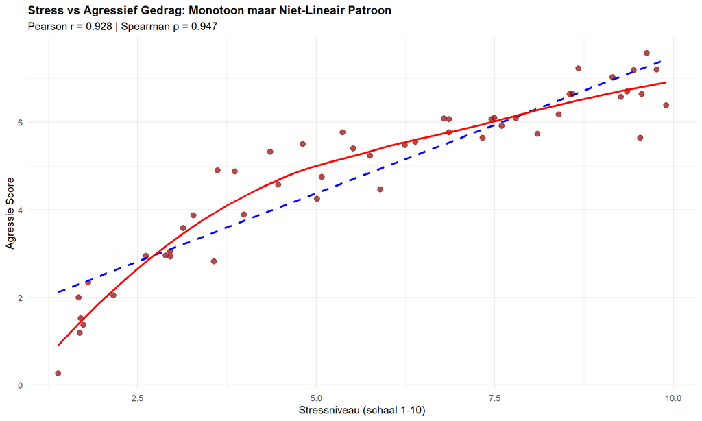

### Vraag Q15 (Toepassen)

**Een criminoloog onderzoekt de relatie tussen sociale binding (attachment) van jongeren met ouders en delinquent gedrag. Ze maakt spreidingsdiagrammen voor verschillende groepen jongeren. In één specifiek diagram ziet ze: een rechte trendlijn die omhoog helt; punten die strak geclusterd zijn rond de lijn met minimale spreiding. Welke beschrijving past het best bij dit patroon?**

> **Hint:** Combineer richting (teken) met sterkte (spreiding).

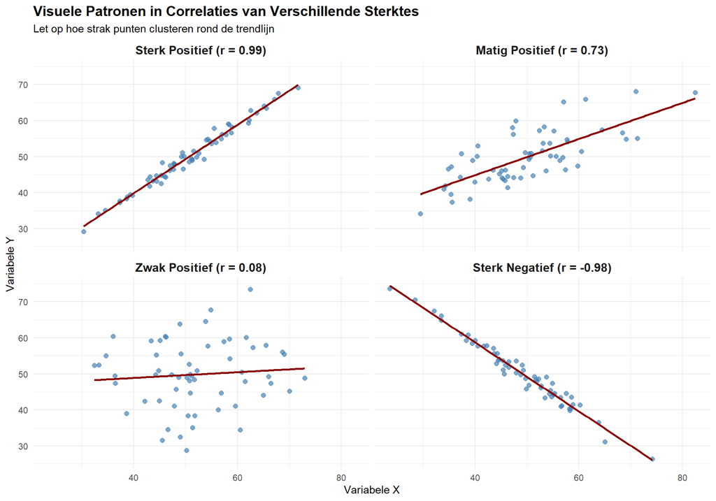

> **Hint:** Combineer richting (omhoog = positief) met sterkte (strakke clustering = sterk). Wat vertelt de minimale spreiding rond de lijn?
1. Sterk positief  
   “1” = ” ✅ Juist! Een strakke wolk van punten die dicht geclusterd zijn rond een opwaarts hellende lijn is de visuele kenmerk van een sterke positieve correlatie (typisch r > 0,7). Dit patroon geeft zowel de richting van de relatie aan (positief — als sociale binding toeneemt, neemt delinquent gedrag betrouwbaar toe) als de sterkte ervan (sterk — punten houden zich dicht aan het lineaire patroon met minimale spreiding). De visualisatie toont minimale afwijking van de trendlijn, wat suggereert een zeer voorspelbare relatie waarbij het kennen van de sociale binding-score nauwkeurige voorspelling van delinquent gedrag mogelijk maakt. In dit criminologische voorbeeld zou zo’n sterk patroon kunnen wijzen op een fundamentele relatie waarbij sterke ouder-kind binding paradoxaal samenhangt met meer delinquentie, met minimale invloed van andere variabelen.”
2. Matig positief  
   “2” = ” ❌ Fout. Het beschreven patroon is veel strakker dan ‘matig’ zou suggereren. Bij een matige positieve correlatie (r ≈ 0,3-0,7) zou je meer spreiding rond de trendlijn zien, met punten die verder van de lijn afliggen. De beschrijving van ‘strak geclusterde punten met minimale spreiding’ duidt op een veel sterkere relatie. In criminologisch onderzoek zou een matige relatie betekenen dat sociale binding wel belangrijk is voor delinquentie-niveaus, maar dat er substantiële variatie bestaat die niet door deze ene factor wordt verklaard. Het patroon in de vraag suggereert echter een veel meer deterministische relatie.”
3. Zwak negatief  
   “3” = ” ❌ Fout. Deze optie mist zowel de richting als de sterkte. De richting is duidelijk positief (omhoog hellende lijn), niet negatief. Bovendien beschrijft de vraag een strak patroon, niet een zwak patroon. Een zwakke negatieve correlatie zou een neerwaarts hellende lijn tonen met veel spreiding rond de lijn. In termen van sociale binding en delinquentie zou een negatieve relatie betekenen dat sterkere binding samengaat met minder delinquentie, wat eigenlijk meer theoretisch logisch zou zijn volgens Hirschi’s sociale controle theorie dan de positieve relatie beschreven in dit voorbeeld.”
4. Geen lineair patroon  
   “4” = ” ❌ Fout. De beschrijving wijst juist op een zeer duidelijk lineair patroon. Punten die ‘strak geclusterd zijn rond een rechte trendlijn’ vormen precies de definitie van een sterk lineair patroon. ‘Geen lineair patroon’ zou betekenen dat de punten willekeurig verspreid zijn zonder enige duidelijke trend, of dat ze een gebogen (curvilineair) patroon volgen. In criminologisch onderzoek zou het ontbreken van een lineair patroon suggereren dat er geen directe, voorspelbare relatie bestaat tussen sociale binding en delinquentie, wat in tegenspraak is met de duidelijke trendlijn beschreven in de vraag.”